# Homework 6

Marcelo Santos Carielo

30/11/2020

## Atividade: Análise de Dados do Coronavírus no Mundo

Aprendemos, através de vários exemplos, como podemos explorar o pacote coronavírus disponível no R. Agora é a sua vez! Nessa atividade, você deverá usar o pacote coronavírus para avaliar questões distintas das que foram propostas na aula. Você pode analisar outras variáveis, ou utilizar as mesmas variáveis a fim de fazer uma análise por região, grupo de países, etc. As possibilidades são imensas e você deverá explorá-las. Coloque em prática todas as ferramentas que aprendemos anteriormente para fazer um relatório sobre a situação do coronavírus. Quanto maior o número de elementos utilizados, maior será a sua nota. Utilize toda a sua criatividade e conhecimento. Bom trabalho!

Resp:

## Análise do coronavírus na América Latina

Para as questões aqui estudadas referentes ao coronavírus iremos utilizar os pacotes vistos em aulas, além do wpp2019 (World Population Prospects 2019) para obtermos a população dos países

Inicialmente, vejamos como tem sido a evolução do coronavírus nos 12 países da América do Sul.

```r
# carrega pacotes
#install.packages("wpp2019")
library(wpp2019)
data(pop)

library(ggplot2)
library(patchwork)
library(lubridate)
library(zoo)
library(dplyr)
#install.packages("coronavirus")
library(coronavirus)
#update_dataset() #obs: colocar Y (yes) no console

#?coronavirus
#names(coronavirus)
#head(coronavirus)

#?wpp2019
#names(pop)
#head(pop$name)

south_america <- c("Argentina", "Bolivia (Plurinational State of)", "Brazil",
                   "Chile", "Colombia", "Ecuador", "Guyana",
                   "Paraguay", "Peru", "Suriname", "Uruguay",
                   "Venezuela (Bolivarian Republic of)")
#length(south_america)

# filtra dados sobre a populacao
population <- pop %>% filter(name %in% south_america) %>%
  unique() %>%
  select(name, "2020") %>%
  rename(total_pop = "2020") %>%
  arrange(name)

dim(population)
```

```
## [1] 12  2
```

```r
#population
population %>% arrange(-total_pop)
```

```
##                                  name  total_pop
## 1                              Brazil 212559.409
## 2                            Colombia  50882.884
## 3                           Argentina  45195.777
## 4                                Peru  32971.846
## 5  Venezuela (Bolivarian Republic of)  28435.943
## 6                               Chile  19116.209
## 7                             Ecuador  17643.060
## 8    Bolivia (Plurinational State of)  11673.029
## 9                            Paraguay   7132.530
## 10                            Uruguay   3473.727
## 11                             Guyana    786.559
## 12                           Suriname    586.634
```

Acima, temos a população de cada um dos países da América Latina em 2020, segundo o wpp2019.

```r
min(coronavirus$date)
```

```
## [1] "2020-01-22"
```

```r
max(coronavirus$date)
```

```
## [1] "2020-11-25"
```

Vejamos um resumo dos dados sobre o total de casos de coronavírus na América Latina para o período que vai de 22/jan/2020 a 25/nov/2020.

```r
south_america_b <- c("Argentina", "Bolivia", "Brazil",
                   "Chile", "Colombia", "Ecuador", "Guyana",
                   "Paraguay", "Peru", "Suriname", "Uruguay",
                   "Venezuela")

total_deaths <- coronavirus %>%
  filter(country %in% south_america_b &
         type == "death") %>%
  group_by(country) %>%
  summarise(total_deaths = sum(cases), .groups="drop")

total_recovered <- coronavirus %>%
  filter(country %in% south_america_b &
         type == "recovered") %>%
  group_by(country) %>%
  summarise(total_recovered = sum(cases), .groups="drop")

latin_america <- coronavirus %>%
  filter(country %in% south_america_b &
         type == "confirmed") %>%
  group_by(country) %>%
  summarise(total_cases = sum(cases), .groups="drop") %>%
  mutate(population = 1000*population$total_pop,
         cases_percentage = round(total_cases/population*100, 2),
         total_recovered = total_recovered$total_recovered,
         total_deaths = total_deaths$total_deaths,
         active_cases = total_cases - total_recovered - total_deaths,
         deaths_per_case_percentage = round(total_deaths/total_cases*100, 2)) %>%
  arrange(-total_cases)

latin_america
```

```
## # A tibble: 12 x 8
##    country total_cases population cases_percentage total_recovered total_deaths
##    <chr>         <int>      <dbl>            <dbl>           <int>        <int>
##  1 Brazil      6166606 212559409              2.9          5534010       170769
##  2 Argent…     1390388  45195777              3.08         1217284        37714
##  3 Colomb…     1270991  50882884              2.5          1174959        35860
##  4 Peru         952439  32971846.             2.89          884747        35685
##  5 Chile        544092  19116209.             2.85          520180        15138
##  6 Ecuador      187230  17643060              1.06          164009        13288
##  7 Bolivia      144276  11673029              1.24          120209         8933
##  8 Venezu…      100817  28435943              0.35           95669          880
##  9 Paragu…       78878   7132530.             1.11           56025         1691
## 10 Surina…        5305    586634.             0.9             5184          117
## 11 Guyana         5236    786559              0.67            4242          147
## 12 Uruguay        4988   3473727              0.14            3923           73
## # … with 2 more variables: active_cases <int>, deaths_per_case_percentage <dbl>
```

```r
#dim(latin_america)
```

Os países com maior e menor número de casos confirmados na América Latina são, respectivamente, o Brasil e Uruguai. Embora o Equador e Bolívia são os países com maior número de mortes por infectados, em termos de volume, o Brasil ocupa o primeiro lugar, tendo alcançado mais do que 167 mil mortes por coronavírus. Isso corresponde a mais de 4 vezes a quantidade de mortes ocorrida em países latinos americanos vizinhos, além de refletir a situação emergencial ocasionada pela pandemia de coronavírus.

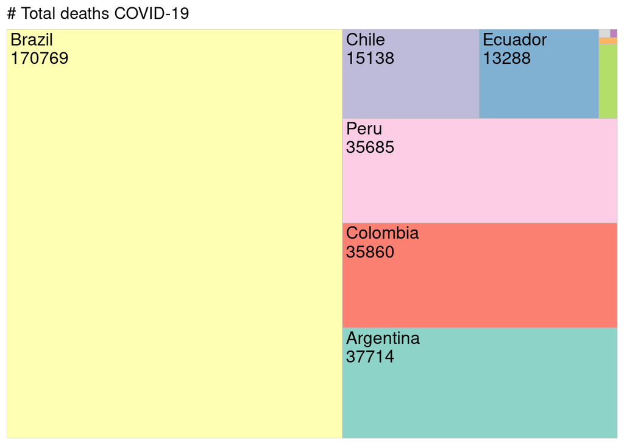

```r
#install.packages("treemapify")
library(treemapify)
#help(geom_treemap)

mortes_covid <- coronavirus %>%
  filter(country %in% south_america &
         type == "death") %>%
  group_by(country) %>%
  summarise(total_cases = sum(cases), .groups="drop") %>%
  arrange(-total_cases) %>%
  ungroup()

#head(mortes_covid)

ggplot(data= mortes_covid,
       aes(area=total_cases, fill=country,
           label = paste(country, total_cases, sep="\n"))) +
   geom_treemap(show.legend=FALSE, layout="scol") +
   geom_treemap_text(colour="black", place="topleft",
                     size=14, reflow=FALSE, grow=FALSE) +
  scale_fill_brewer(palette="Set3") +
  labs(title = "# Total deaths COVID-19",
             y = NULL,
             x = NULL)
```

```r
latin_america %>% arrange(-total_deaths) %>%
  select(country, total_cases, total_deaths)
```

```
## # A tibble: 12 x 3
##    country   total_cases total_deaths
##    <chr>           <int>        <int>
##  1 Brazil        6166606       170769
##  2 Argentina     1390388        37714
##  3 Colombia      1270991        35860
##  4 Peru           952439        35685
##  5 Chile          544092        15138
##  6 Ecuador        187230        13288
##  7 Bolivia        144276         8933
##  8 Paraguay        78878         1691
##  9 Venezuela      100817          880
## 10 Guyana           5236          147
## 11 Suriname         5305          117
## 12 Uruguay          4988           73
```

Os dados do dataset coronavírus utilizados para criar a tabela acima, ordenada pela quantidade total de mortes por coronavírus, fornecem o seguinte gráfico:

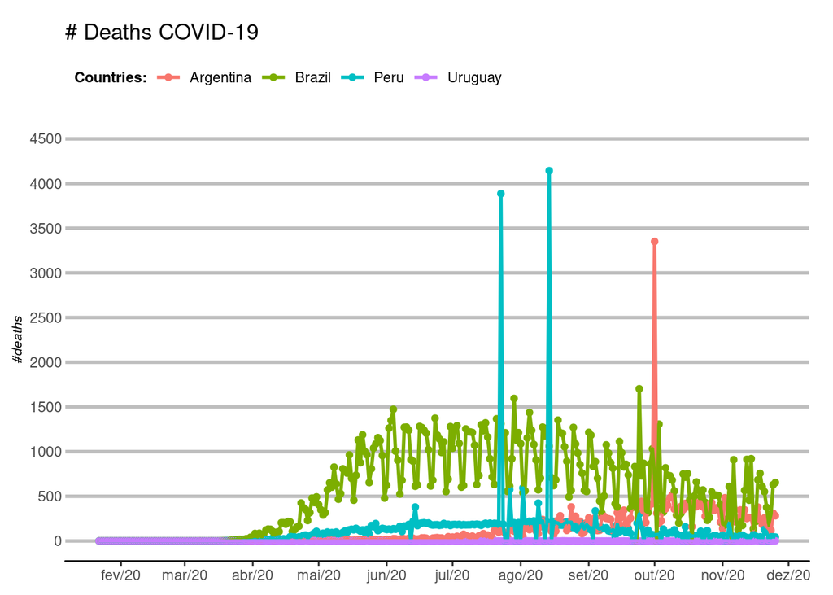

```r
#names(coronavirus)
#?quantile

total_deaths1 <- coronavirus %>%
  filter(country %in% c("Brazil", "Argentina", "Peru", "Uruguay") &
         type == "death") %>%
  group_by(date, country, cases) %>%
  summarise(total_deaths = sum(cases), .groups="drop") %>%
  arrange(date)

g1 <- ggplot(data=total_deaths1, aes(x=date, y=cases, colour=country)) +
  geom_point() +
  geom_line(size = 1) +
  scale_x_date(date_breaks = "1 month", date_minor_breaks = "1 week",
             date_labels = "%b/%y") +
  scale_y_continuous(limits = c(0, 4500), breaks = seq(0, 4500, 500)) +
  labs(title = "# Deaths COVID-19",
             y = "#deaths",
             x = NULL,
       color = "Countries:") +
  theme_classic() +
  guides( col = guide_legend(nrow = 1))+
  theme(axis.title=element_text(size=8, face="italic"),
        plot.caption = element_text(hjust = 0.0, size=8),
        axis.line.y = element_blank(),
        axis.line.x = element_line(lineend="round"),
        axis.ticks.length.x =unit(0.2, "lines"),
        axis.ticks.length.y =unit(0, "lines"),
        axis.ticks.y = element_line(colour= "gray", size=1),
        legend.background=element_rect(fill="white", colour=NA),
        legend.position='top',
        legend.justification='left',
        legend.direction='horizontal',
        legend.title=element_text(size=rel(0.8), face="bold", hjust=0),
        panel.background=element_blank(),
        panel.border=element_blank(),
        panel.grid.minor = element_blank(),
        panel.grid.major.y = element_line(colour= "gray",size=1),
        plot.margin=unit(c(1, 1, 0.5, 0.5), "lines"),
        plot.title=element_text(size=rel(1.2)),
        strip.background=element_rect(fill="grey90", colour="grey50"),
        strip.text.y=element_text(size=rel(0.8), angle=-90)
  )

g1
```

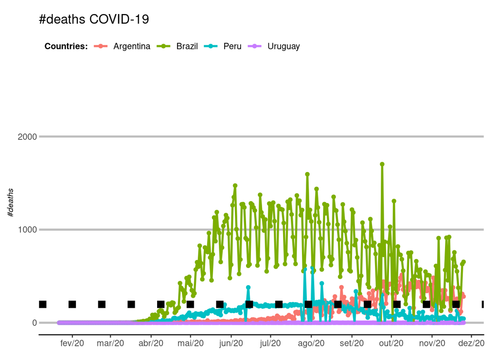

```r
total_deaths1 <- coronavirus %>%
  filter(country %in% c("Brazil", "Argentina", "Peru", "Uruguay") &
         type == "death") %>%
  group_by(date, country, cases) %>%
  summarise(total_deaths = sum(cases), .groups="drop") %>%
  arrange(date)

g1b <- ggplot(data=total_deaths1, aes(x=date, y=cases, colour=country)) +
  geom_point(na.rm=TRUE) +
  geom_line(size = 1) +
  geom_hline(yintercept = mean(total_deaths1$cases, na.rm=TRUE),
             linetype = 3, size=3.5, color="black") +
#  geom_smooth(method = "lm", color = "red")
  scale_x_date(date_breaks = "1 month", date_minor_breaks = "1 week",
             date_labels = "%b/%y") +
    ylim(0, quantile(total_deaths1$cases, 0.998)) +
  labs(title = "#deaths COVID-19",
             y = "#deaths",
             x = NULL,
       color = "Countries:") +
  theme_classic() +
  guides( col = guide_legend(nrow = 1))+
  theme(axis.title=element_text(size=8, face="italic"),
        plot.caption = element_text(hjust = 0.0, size=8),
        axis.line.y = element_blank(),
        axis.line.x = element_line(lineend="round"),
        axis.ticks.length.x =unit(0.2, "lines"),
        axis.ticks.length.y =unit(0, "lines"),
        axis.ticks.y = element_line(colour= "gray", size=1),
        legend.background=element_rect(fill="white", colour=NA),
        legend.position='top',
        legend.justification='left',
        legend.direction='horizontal',
        legend.title=element_text(size=rel(0.8), face="bold", hjust=0),
        panel.background=element_blank(),
        panel.border=element_blank(),
        panel.grid.minor = element_blank(),
        panel.grid.major.y = element_line(colour= "gray",size=1),
        plot.margin=unit(c(1, 1, 0.5, 0.5), "lines"),
        plot.title=element_text(size=rel(1.2)),
        strip.background=element_rect(fill="grey90", colour="grey50"),
        strip.text.y=element_text(size=rel(0.8), angle=-90)
  )

g1b
```

O gráfico acima mostra que de abril até meados de novembro deste ano, o Brasil foi o país com maior número de mortes em cada mês.

```r
round(mean(total_deaths1$cases))
```

```
## [1] 198
```

## Análises para o mês de novembo de 2020

Vejamos a evolução da pandemia na América Latina para o mês de novembro.

```r
library(tidyr)
#max(coronavirus$date)

data_november <- coronavirus %>%  filter(country %in% south_america_b &
                          date >= '2020-11-01' & date <= '2020-11-25' &
                          type == "death") %>%
  group_by(country, type, date) %>%
  summarise(total_cases=sum(cases), .groups="drop") %>%
  pivot_wider(names_from=type,
              values_from=total_cases)# %>%
  #arrange(-death)


data_november
```

```
## # A tibble: 300 x 3
##    country   date       death
##    <chr>     <date>     <int>
##  1 Argentina 2020-11-01   138
##  2 Argentina 2020-11-02   483
##  3 Argentina 2020-11-03   429
##  4 Argentina 2020-11-04   468
##  5 Argentina 2020-11-05   246
##  6 Argentina 2020-11-06   370
##  7 Argentina 2020-11-07   212
##  8 Argentina 2020-11-08   212
##  9 Argentina 2020-11-09   347
## 10 Argentina 2020-11-10   276
## # … with 290 more rows
```

```r
round(mean(data_november$death, na.rm=TRUE))
```

```
## [1] 85
```

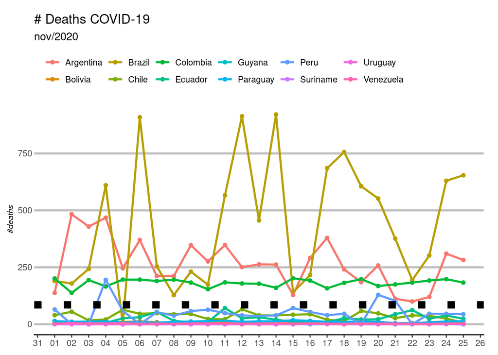

```r
g1c <- ggplot(data=data_november, aes(x=date, y=death, colour=country)) +
  geom_point(na.rm=TRUE) +
  geom_line(size = 1) +
  geom_hline(yintercept = mean(data_november$death, na.rm=TRUE),
             linetype = 3, size=3.5, color="black") +
  scale_x_date(date_breaks = "1 day", date_minor_breaks = "1 week",
             date_labels = "%d") +
  labs(title = "# Deaths COVID-19",
       subtitle = "nov/2020",
             y = "#deaths",
             x = NULL,
       color = NULL) +
  theme_classic() +
  guides(col = guide_legend(nrow = 2))+
  theme(axis.title=element_text(size=8, face="italic"),
        plot.caption = element_text(hjust = 0.0, size=8),
        axis.line.y = element_blank(),
        axis.line.x = element_line(lineend="round"),
        axis.ticks.length.x =unit(0.2, "lines"),
        axis.ticks.length.y =unit(0, "lines"),
        axis.ticks.y = element_line(colour= "gray", size=1),
        legend.background=element_rect(fill="white", colour=NA),
        legend.position='top',
        legend.justification='left',
        legend.direction='horizontal',
        legend.title=element_text(size=rel(0.8), face="bold", hjust=1),
        panel.background=element_blank(),
        panel.border=element_blank(),
        panel.grid.minor = element_blank(),
        panel.grid.major.y = element_line(colour= "gray",size=1),
        plot.margin=unit(c(1, 1, 0.5, 0.5), "lines"),
        plot.title=element_text(size=rel(1.2)),
        strip.background=element_rect(fill="Set3", colour="Set2"),
        strip.text.y=element_text(size=rel(0.8), angle=-90)
  )

g1c
```

## COVID-19 no Brasil paa o mês de novembro de 2020

```r
data_november_br <- coronavirus %>%  filter(country== "Brazil" &
                          date >= '2020-11-01' & date <= '2020-11-25' &
                          type == "death") %>%
  group_by(country, type, date) %>%
  summarise(total_cases=sum(cases), .groups="drop") %>%
  pivot_wider(names_from=type,
              values_from=total_cases)

data_november_br
```

```
## # A tibble: 25 x 3
##    country date       death
##    <chr>   <date>     <int>
##  1 Brazil  2020-11-01   190
##  2 Brazil  2020-11-02   179
##  3 Brazil  2020-11-03   243
##  4 Brazil  2020-11-04   610
##  5 Brazil  2020-11-05     0
##  6 Brazil  2020-11-06   909
##  7 Brazil  2020-11-07   254
##  8 Brazil  2020-11-08   128
##  9 Brazil  2020-11-09   231
## 10 Brazil  2020-11-10   174
## # … with 15 more rows
```

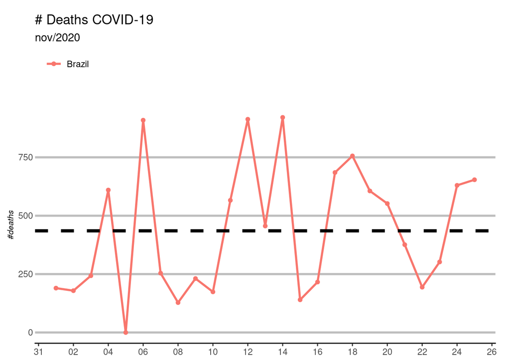

```r
g1d <- ggplot(data=data_november_br, aes(x=date, y=death, colour=country)) +
  geom_point(na.rm=TRUE) +
  geom_line(size = 1) +
  geom_hline(yintercept = mean(data_november_br$death, na.rm=TRUE),
             linetype = 2, size=1.5, color="black") +
  scale_x_date(date_breaks = "2 day", date_minor_breaks = "1 week",
             date_labels = "%d") +
  labs(title = "# Deaths COVID-19",
       subtitle = "nov/2020",
             y = "#deaths",
             x = NULL,
       color = NULL) +
  theme_classic() +
  guides(col = guide_legend(nrow = 2))+
  theme(axis.title=element_text(size=8, face="italic"),
        plot.caption = element_text(hjust = 0.0, size=8),
        axis.line.y = element_blank(),
        axis.line.x = element_line(lineend="round"),
        axis.ticks.length.x =unit(0.2, "lines"),
        axis.ticks.length.y =unit(0, "lines"),
        axis.ticks.y = element_line(colour= "gray", size=1),
        legend.background=element_rect(fill="white", colour=NA),
        legend.position='top',
        legend.justification='left',
        legend.direction='horizontal',
        legend.title=element_text(size=rel(0.8), face="bold", hjust=1),
        panel.background=element_blank(),
        panel.border=element_blank(),
        panel.grid.minor = element_blank(),
        panel.grid.major.y = element_line(colour= "gray",size=1),
        plot.margin=unit(c(1, 1, 0.5, 0.5), "lines"),
        plot.title=element_text(size=rel(1.2)),
        strip.background=element_rect(fill="Set3", colour="Set2"),
        strip.text.y=element_text(size=rel(0.8), angle=-90)
  )
g1d
```

```r
round(mean(data_november_br$death, na.rm=TRUE))
```

```
## [1] 435
```

Olhando para o mÊs de novembro não é possível notar uma tendência que indique alguma possível estabilização do número de mortes por coronavírus no Brasil.

## Evolução do COVID-19 no Brasil

```r
data_br <- coronavirus %>%  filter(country== "Brazil" &
                          type == "death") %>%
  group_by(country, type, date) %>%
  summarise(total_cases=sum(cases), .groups="drop") %>%
  pivot_wider(names_from=type,
              values_from=total_cases)

data_br
```

```
## # A tibble: 309 x 3
##    country date       death
##    <chr>   <date>     <int>
##  1 Brazil  2020-01-22     0
##  2 Brazil  2020-01-23     0
##  3 Brazil  2020-01-24     0
##  4 Brazil  2020-01-25     0
##  5 Brazil  2020-01-26     0
##  6 Brazil  2020-01-27     0
##  7 Brazil  2020-01-28     0
##  8 Brazil  2020-01-29     0
##  9 Brazil  2020-01-30     0
## 10 Brazil  2020-01-31     0
## # … with 299 more rows
```

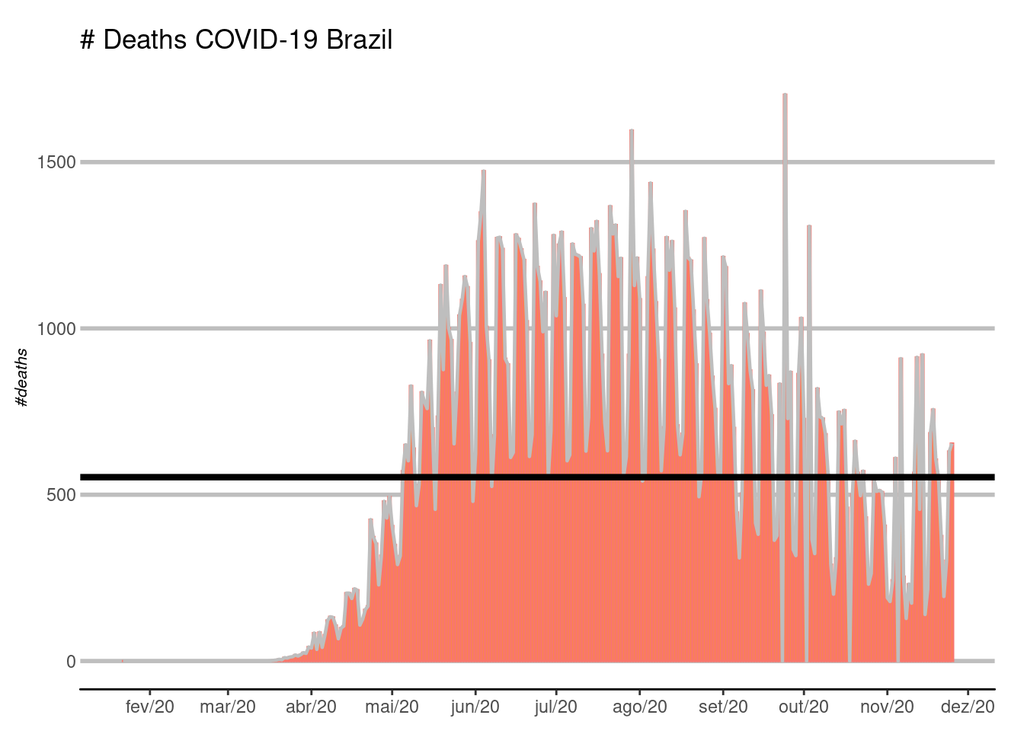

```r
g1f <- ggplot(data=data_br, aes(x=date, y=death, colour=country)) +
  geom_col(mapping = aes(x=date, y=death), fill = "orange") +
  geom_line(size=0.8, color="gray") +
  geom_hline(yintercept = mean(data_br$death, na.rm=TRUE),
             linetype=1, size=1.5, color="black") +
  scale_x_date(date_breaks = "1 month", date_minor_breaks = "1 month",
             date_labels = "%b/%y") +
  labs(title = "# Deaths COVID-19 Brazil",
       y = "#deaths",
       x = NULL,
       color = NULL) +
  theme_classic() +
  guides(col = guide_legend(nrow = 1))+
  theme(axis.title=element_text(size=8, face="italic"),
        plot.caption = element_blank(), #element_text(hjust = 0.0, size=8),
        axis.line.y = element_blank(),
        axis.line.x = element_line(lineend="round"),
        axis.ticks.length.x =unit(0.2, "lines"),
        axis.ticks.length.y =unit(0, "lines"),
        axis.ticks.y = element_line(colour= "gray", size=1),
        legend.background=element_rect(fill="white", colour=NA),
        legend.position="none",#'top',
        legend.justification='left',
        legend.direction='horizontal',
        legend.title=element_blank(), #element_text(size=rel(0.8), face="bold", hjust=1),
        panel.background=element_blank(),
        panel.border=element_blank(),
        panel.grid.minor = element_blank(),
        panel.grid.major.y = element_line(colour= "gray",size=1),
        plot.margin=unit(c(1, 1, 0.5, 0.5), "lines"),
        plot.title=element_text(size=rel(1.2)),
        strip.background=element_rect(fill="Set3", colour="Set2"),
        strip.text.y=element_text(size=rel(0.8), angle=-90)
  )

g1f
```

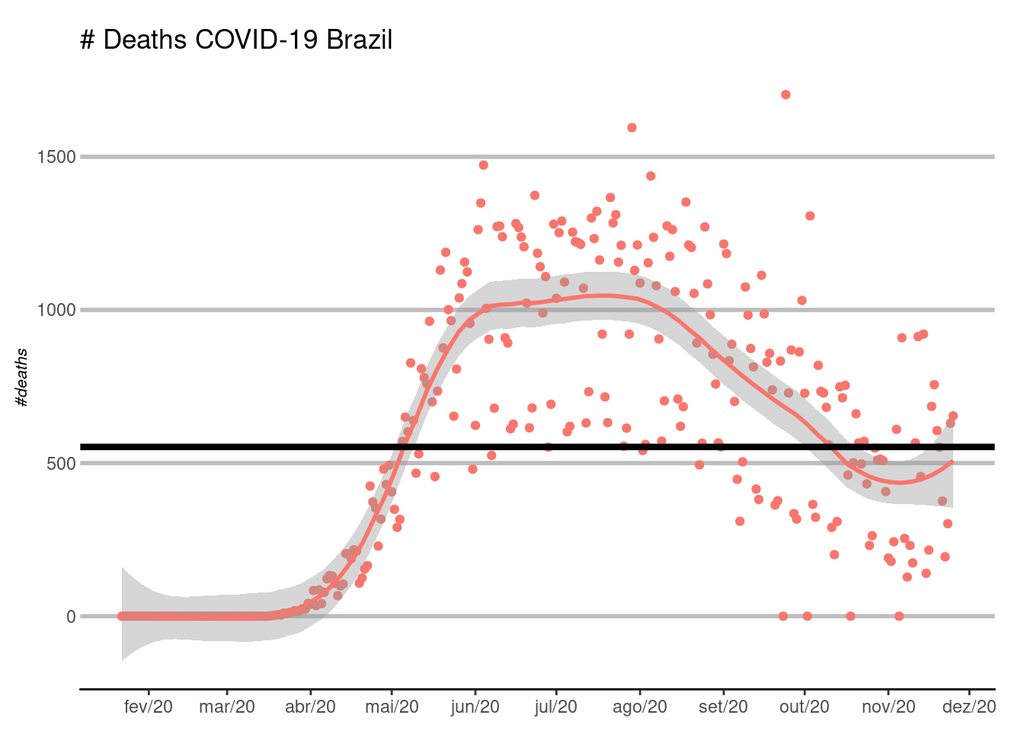

```r
?geom_smooth()
g1g <- ggplot(data=data_br, aes(x=date, y=death, colour=country)) +
  geom_point() +
  stat_smooth(method="loess", span=0.3, formula = y ~ poly(x, 1)) +
  geom_hline(yintercept = mean(data_br$death, na.rm=TRUE),
             linetype=1, size=1.5, color="black") +
  scale_x_date(date_breaks = "1 month", date_minor_breaks = "1 month",
             date_labels = "%b/%y") +
  labs(title = "# Deaths COVID-19 Brazil",
       y = "#deaths",
       x = NULL,
       color = NULL) +
  theme_classic() +
  guides(col = guide_legend(nrow = 1))+
  theme(axis.title=element_text(size=8, face="italic"),
        plot.caption = element_blank(), #element_text(hjust = 0.0, size=8),
        axis.line.y = element_blank(),
        axis.line.x = element_line(lineend="round"),
        axis.ticks.length.x =unit(0.2, "lines"),
        axis.ticks.length.y =unit(0, "lines"),
        axis.ticks.y = element_line(colour= "gray", size=1),
        legend.background=element_rect(fill="white", colour=NA),
        legend.position="none",#'top',
        legend.justification='left',
        legend.direction='horizontal',
        legend.title=element_blank(), #element_text(size=rel(0.8), face="bold", hjust=1),
        panel.background=element_blank(),
        panel.border=element_blank(),
        panel.grid.minor = element_blank(),
        panel.grid.major.y = element_line(colour= "gray",size=1),
        plot.margin=unit(c(1, 1, 0.5, 0.5), "lines"),
        plot.title=element_text(size=rel(1.2)),
        strip.background=element_rect(fill="Set3", colour="Set2"),
        strip.text.y=element_text(size=rel(0.8), angle=-90)
  )

g1g
```

```r
round(mean(data_br$death, na.rm=TRUE))
```

```
## [1] 553
```

Analisando a evolução do coronavírus desde o início de 2020 até o presente momento, pelo gráfico acima, nota-se que embora haja uma tendência de decaimento após agosto, no mês de novembro há um aumento no número de mortes por coronavírus. Destaca-se ainda que a média para o período é de 553 ao dia. Ainda não é possível afirmar que há uma tendência de diminuição efetiva no número de mortes, sendo que a curva exibida acima mostra o reflexo do efeito de uma mitigação inadequada no combate a pandemia.

## COVID-19 segunda onda

```r
data_br_cases <- coronavirus %>%  filter(country== "Brazil" &
                          type == "confirmed") %>%
  group_by(country, type, date) %>%
  summarise(total_cases=sum(cases), .groups="drop") %>%
  pivot_wider(names_from=type,
              values_from=total_cases)

data_br_cases
```

```
## # A tibble: 309 x 3
##    country date       confirmed
##    <chr>   <date>         <int>
##  1 Brazil  2020-01-22         0
##  2 Brazil  2020-01-23         0
##  3 Brazil  2020-01-24         0
##  4 Brazil  2020-01-25         0
##  5 Brazil  2020-01-26         0
##  6 Brazil  2020-01-27         0
##  7 Brazil  2020-01-28         0
##  8 Brazil  2020-01-29         0
##  9 Brazil  2020-01-30         0
## 10 Brazil  2020-01-31         0
## # … with 299 more rows
```

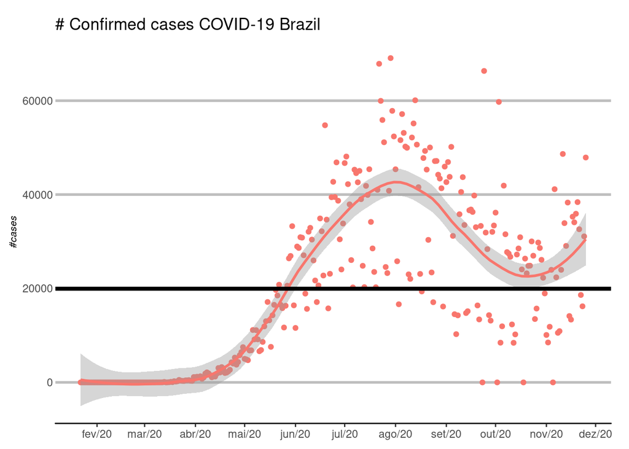

```r
g2 <- ggplot(data=data_br_cases, aes(x=date, y=confirmed, colour=country)) +
  geom_point() +
  stat_smooth(method="loess", span=0.4, formula = y ~ poly(x, 1)) +
  geom_hline(yintercept = mean(data_br_cases$confirmed, na.rm=TRUE),
             linetype=1, size=1.5, color="black") +
  scale_x_date(date_breaks = "1 month", date_minor_breaks = "1 month",
             date_labels = "%b/%y") +
  labs(title = "# Confirmed cases COVID-19 Brazil",
             y = "#cases",
             x = NULL,
       color = NULL) +
  theme_classic() +
  guides(col = guide_legend(nrow = 1))+
  theme(axis.title=element_text(size=8, face="italic"),
        plot.caption = element_blank(), #element_text(hjust = 0.0, size=8),
        axis.line.y = element_blank(),
        axis.line.x = element_line(lineend="round"),
        axis.ticks.length.x =unit(0.2, "lines"),
        axis.ticks.length.y =unit(0, "lines"),
        axis.ticks.y = element_line(colour= "gray", size=1),
        legend.background=element_rect(fill="white", colour=NA),
        legend.position="none",#'top',
        legend.justification='left',
        legend.direction='horizontal',
        legend.title=element_blank(), #element_text(size=rel(0.8), face="bold", hjust=1),
        panel.background=element_blank(),
        panel.border=element_blank(),
        panel.grid.minor = element_blank(),
        panel.grid.major.y = element_line(colour= "gray",size=1),
        plot.margin=unit(c(1, 1, 0.5, 0.5), "lines"),
        plot.title=element_text(size=rel(1.2)),
        strip.background=element_rect(fill="Set3", colour="Set2"),
        strip.text.y=element_text(size=rel(0.8), angle=-90)
  )

g2
```

```r
round(mean(data_br_cases$confirmed, na.rm=TRUE))
```

```
## [1] 19957
```

Segundo especialistas, esse aumento se deve a ineficiência na implementação de medidas para combater o coronavírus. De fato, isso mostra que as várias recomendações no combate a doença não seguidas por muitos estados brasileiros começa a surtir efeito negativo no que tange a evolução da pandemia de coronavírus.

```r
library(zoo)
library(tidyr)

data_br_cases_deaths <- coronavirus %>%  filter(country== "Brazil" &
                          (type == "confirmed" | type == "death" )) %>%
  group_by(country, type, date) %>%
  summarise(total_cases=sum(cases), .groups="drop") %>%
  pivot_wider(names_from=type,
              values_from=total_cases)
head(data_br_cases_deaths)
```

```
## # A tibble: 6 x 4
##   country date       confirmed death
##   <chr>   <date>         <int> <int>
## 1 Brazil  2020-01-22         0     0
## 2 Brazil  2020-01-23         0     0
## 3 Brazil  2020-01-24         0     0
## 4 Brazil  2020-01-25         0     0
## 5 Brazil  2020-01-26         0     0
## 6 Brazil  2020-01-27         0     0
```

```r
names(data_br_cases_deaths)
```

```
## [1] "country"   "date"      "confirmed" "death"
```

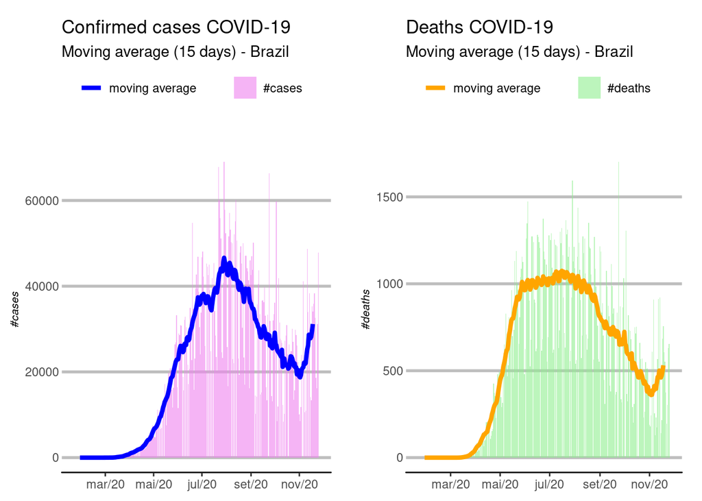

```r
movel <- data_br_cases_deaths %>%
  mutate(média_móvel15=zoo::rollmean(confirmed, k=15, fill = NA, na.rm=TRUE))
#movel

g3 <- ggplot(data=movel, aes(x=date)) +
  geom_bar(aes(y = confirmed, fill="#cases"),
           stat="identity",  alpha=0.6, na.rm=TRUE) +
  geom_line(mapping=aes(x = date, y = média_móvel15, color="moving average"),
            size=1.5, na.rm=TRUE) +
  scale_colour_manual(" ", values=c("#cases"="violet", "moving average"="blue")) +
  scale_fill_manual("",values="violet") +
  labs(title = "Confirmed cases COVID-19",
                  subtitle = "Moving average (15 days) - Brazil",
                  y = "#cases",
                  x = NULL) +
  scale_x_date(date_breaks = "2 month", date_minor_breaks = "1 month",
             date_labels = "%b/%y") +
  theme_classic() +
  guides(col = guide_legend(nrow = 2))+
  theme(axis.title=element_text(size=8, face="italic"),
        plot.caption = element_text(hjust = 0.0, size=8),
        axis.line.y = element_blank(),
        axis.line.x = element_line(lineend="round"),
        axis.ticks.length.x =unit(0.2, "lines"),
        axis.ticks.length.y =unit(0, "lines"),
        axis.ticks.y = element_line(colour= "gray", size=1),
        legend.background=element_rect(fill="white", colour=NA),
        legend.position='top',
        legend.justification='left',
        legend.direction='horizontal',
        legend.title=element_text(size=rel(0.8), face="bold", hjust=1),
        panel.background=element_blank(),
        panel.border=element_blank(),
        panel.grid.minor = element_blank(),
        panel.grid.major.y = element_line(colour= "gray",size=1),
        plot.margin=unit(c(1, 1, 0.5, 0.5), "lines"),
        plot.title=element_text(size=rel(1.2)),
        strip.background=element_rect(fill="Set3", colour="Set2"),
        strip.text.y=element_text(size=rel(0.8), angle=-90)
  )

movelb <- data_br_cases_deaths %>%
  mutate(média_móvel15=zoo::rollmean(death, k=15, fill = NA, na.rm=TRUE))


g4 <- ggplot(data=movelb, aes(x=date)) +
  geom_bar(aes(y=death, fill="#deaths"),
           stat="identity",  alpha=0.6, na.rm=TRUE) +
  geom_line(mapping=aes(x=date, y=média_móvel15, color="moving average"),
            size=1.5, na.rm=TRUE) +
  scale_colour_manual(" ", values=c("#deaths"="lightgreen", "moving average"="orange")) +
  scale_fill_manual("",values="lightgreen") +
  labs(title = "Deaths COVID-19",
                  subtitle = "Moving average (15 days) - Brazil",
                  y = "#deaths",
                  x = NULL) +
  scale_x_date(date_breaks = "2 month", date_minor_breaks = "1 month",
             date_labels = "%b/%y") +
  theme_classic() +
  guides(col = guide_legend(nrow = 2))+
  theme(axis.title=element_text(size=8, face="italic"),
        plot.caption = element_text(hjust = 0.0, size=8),
        axis.line.y = element_blank(),
        axis.line.x = element_line(lineend="round"),
        axis.ticks.length.x =unit(0.2, "lines"),
        axis.ticks.length.y =unit(0, "lines"),
        axis.ticks.y = element_line(colour= "gray", size=1),
        legend.background=element_rect(fill="white", colour=NA),
        legend.position='top',
        legend.justification='left',
        legend.direction='horizontal',
        legend.title=element_text(size=rel(0.8), face="bold", hjust=1),
        panel.background=element_blank(),
        panel.border=element_blank(),
        panel.grid.minor = element_blank(),
        panel.grid.major.y = element_line(colour= "gray",size=1),
        plot.margin=unit(c(1, 1, 0.5, 0.5), "lines"),
        plot.title=element_text(size=rel(1.2)),
        strip.background=element_rect(fill="Set3", colour="Set2"),
        strip.text.y=element_text(size=rel(0.8), angle=-90)
  )



library("gridExtra")
grid.arrange(g3, g4, nrow=1, ncol=2)
```

Os gráficos acima mostram a proximidade na evolução entre o número de mortes por coronavírus e o número de casos. Nota-se que ambos valores possuem muita semelhança, sendo que o mês no novembro notamos o a tendência de um novo crescimento de coronavírus no Brasil.

## Referências

[1] R package: coronavirus https://github.com/RamiKrispin/coronavirus

[2] COVID-19 pandemic https://en.wikipedia.org/wiki/COVID-19_pandemic

[3] Coronavírus: ‘Brasil já está na 2ª onda de covid-19’, diz pesquisador da USP https://www.bbc.com/portuguese/brasil-54982109